# Evidencia 2 | Proyecto Integrador

Biniza Verónica Vázquez Moreno A01737294

2026-04-28

## Parte 1: Investigación sobre COVID-19

### ¿Cuál es la situación actual de COVID-19 a nivel mundial?

#### A nivel mundial

En el período del 16 de febrero al 15 de marzo de 2026, un total de 80 países reportaron 38,516 nuevos casos de COVID-19 a la OMS, una cifra menor comparada con los 50,752 casos del período anterior. Trece países de África, América y Europa registraron incrementos superiores al 10% (WHO COVID-19 Dashboard, s.f.). La variante XFG es actualmente la más prevalente a nivel global, representando el 50.8% de las secuencias analizadas en la semana del 8 de marzo de 2026. En general, el virus sigue circulando pero a niveles significativamente menores que durante la pandemia.

La variante más reciente del virus es la Stratus, reportada a finales de 2025, la cual ha producido olas de infección menores, caracterizadas por rasgos acumulativos de inmunidad híbrida.

De manera más específica, en la ventana de 28 días con corte al 22 de febrero de 2026, la OMS documentó 5,295 hospitalizaciones, 211 internamientos en terapia intensiva y 1,540 muertes. Se estima que el 89% de estos decesos ocurrió en pacientes mayores de 65 años. Esto confirma que el COVID-19 ha evolucionado hasta convertirse en una enfermedad de temporada que amenaza principalmente a los sectores poblacionales más vulnerables.

#### En México

México registró 7,186 casos confirmados de COVID-19 y 268 defunciones con corte a la semana epidemiológica 49 de 2025, según la Dirección General de Epidemiología (Secretaría de Salud, 2025). El virus continúa activo pero dentro de niveles controlados y bajo vigilancia continua junto con influenza y otros virus respiratorios.

#### En el estado de Puebla

Al corte del 15 de septiembre de 2025, Puebla acumulaba 384 casos positivos con una tasa de letalidad del 4.4%, siendo el segundo estado con más muertes por COVID-19 en el país en ese año, con 17 defunciones que representan el 7.7% del total nacional (Morales, 2025). Para diciembre de 2025, la Secretaría de Salud de Puebla reportó 414 casos activos y 19 defunciones asociadas al virus durante la temporada invernal, con más de 111,717 dosis de vacuna aplicadas en el año (Diario Cambio, 2025).

### Primera variante que se propagó al mundo

La primera variante reconocida oficialmente fue la variante **Alfa** (B.1.1.7), que surgió en septiembre de 2020 en el Reino Unido y fue designada como variante de preocupación el 18 de diciembre de 2020 (Eiros y Hernández, 2022). El genoma de referencia Wuhan-Hu-1 (GenBank MN908947), con 29,903 nucleótidos, fue liberado al mundo por Zhang Yongzhen el 10 de enero de 2020 vía el sitio virological.org.

La mutación D614G de la proteína Spike se extendió por todo el mundo en la primavera de 2020 (representando más del 93% de las secuencias latinoamericanas a finales de ese año, según Leite et al., 2022), y definió el linaje B.1. A continuación, la OMS designó cinco variantes de preocupación: Alfa (B.1.1.7, Reino Unido, septiembre de 2020), Beta (B.1.351, Sudáfrica, mayo de 2020), Gamma (P.1, Brasil/Japón, noviembre de 2020), Delta (B.1.617.2, India, octubre de 2020) y Ómicron (B.1.1.529, Sudáfrica/Botsuana, noviembre de 2021) (Siddiqui et al., 2022).

### Otras variantes en el mundo

A lo largo de la pandemia se han designado 13 variantes principales con letras del alfabeto griego: Alfa, Beta, Gamma, Delta, Épsilon, Dseta, Eta, Zeta, Iota, Kappa, Lambda, Mu y Ómicron (Bupa Salud, s.f.). De estas, Ómicron fue la más significativa por su alta transmisibilidad y sus múltiples sublinajes. En 2026, la variante predominante es la **XFG**, que actualmente lidera la circulación en Estados Unidos y otros países (Gaceta Médica, 2025).

### ¿Cómo buscar información sobre variantes en tu país?

Puebla no cuenta con un control público específico para las variantes; sus datos se incorporan al conjunto nacional de **CoViGen-Mex** en la plataforma COVID-TRACKER. En total, México ha secuenciado 94,799 genomas hasta septiembre de 2024, lo que representa aproximadamente el 2% de los casos confirmados, cifra que está muy por debajo del umbral del 5% recomendado por la OMS. Esto ha significado que la detección de variantes emergentes en México se ha retrasado de forma consistente (Taboada et al., 2021).

### ¿Qué harías en el caso de Li Wenliang?

> **Opción elegida:** Reportarlo al centro de investigación o la universidad.

Si me encontrara en una situación similar a la del Dr. Li Wenliang, elegiría reportar el brote al centro de investigación o la universidad. Mi razonamiento parte de asumir que me ubico en un contexto donde el gobierno no intentaría silenciarme. Guardar la información implicaría poner en riesgo a gran parte de la población, ya que un virus de transmisión respiratoria podría propagarse rápidamente. Revelarla directamente a la prensa presenta dos riesgos: que la población entre en pánico afectando una respuesta coordinada, o bien que ignore la advertencia. Lo más sensato es canalizarla a un centro de investigación o universidad, donde equipos especializados puedan estudiar el patógeno y buscar una solución de forma sistemática y fundamentada.

## Parte 2: Análisis de secuencias en R

## Preparación del entorno de desarrollo

Para este análisis se añadieron las librerías requeridas como fue visto en clase y se reutilizó el archivo compartido `globalSetup.R`, el cual centraliza la carga de paquetes y la definición de rutas de trabajo. De esta forma, el reporte queda más limpio y evita repetir un bloque largo de configuración dentro del documento.

## Carga de secuencias

Cargamos las secuencias de ARN del SARS-CoV-2 a partir de los archivos FASTA descargados, utilizando la función `read_project_fastas()` definida en el bloque de configuración. Esto nos permitirá tener un objeto `DNAStringSet` con todas las secuencias organizadas y listas para su análisis.

```r
sequences <- read_project_fastas()
sequences
```

```
## DNAStringSet object of length 49:
##      width seq                                              names
##  [1] 29763 AGATCTGTTCTCTAAACGAACTT...ATTAATTTTAGTAGTGCTATCC USA_WT
##  [2] 29855 ATTAAAGGTTTATACCTTTCCAG...CTTCTTAGGAGAATGACAAAAA RaTG13_RaTG13
##  [3] 29885 ATTAAAGGTTTATACCTTCCCAG...AAAAAAAAAAAAAAAAAAAAAA GHA_WT
##  [4] 29873 ATTAAAGGTTTATACCTTCCTAG...AAAAAAAAAAAAAAAAAAAAAA HKG_WT
##  [5] 29784 CTTTCGATCTCTTGTAGATCTGT...ATTAATTTTAGTAGTGCTATCC THA_WT
##  ...   ... ...
## [45] 29521 CACGCAGTATAATTAATAACTAA...AGAGCCACCACATTTTCACCGA MT121216.1 Pangol...
## [46] 29856 TTAAAGGTTTATACCTTCCCAGG...GTGATTTTAATAGCTTCTTAGG OR578388.1 |Sever...
## [47] 29441 GCTCGTACGTGGCTTTGGAGACT...ATTAATTTTAGTAGTGCTATCC ON835143.1 Severe...
## [48] 29792 CTTTCGATCTCTTGTAGATCTGT...ATCCCCATGTGATTTTAATAGC MZ611975.1 Severe...
## [49] 29903 ATTAAAGGTTTATACCTTCCCAG...AAAAAAAAAAAAAAAAAAAAAA NC_045512.2 Sever...
```

## Cálculo de la longitud de las secuencias de cada variante

Una vez cargadas las secuencias, calculamos la longitud de cada una utilizando la función `width()` de Biostrings, que devuelve el número de nucleótidos en cada secuencia. Esto nos permitirá comparar las longitudes entre las diferentes variantes y detectar posibles anomalías o diferencias significativas.

Usamos `width()` ya que es la función específica para objetos `DNAStringSet` y es más eficiente que otras alternativas para este tipo de datos.

```r
## LONGITUDES
cat("Sequence lengths:\n")
```

```
## Sequence lengths:
```

```r
for (i in seq_along(sequences)) {
    cat(names(sequences)[i], ":", width(sequences)[i], "\n")
}
```

```
## USA_WT : 29763
## RaTG13_RaTG13 : 29855
## GHA_WT : 29885
## HKG_WT : 29873
## THA_WT : 29784
## DEU_Beta : 29827
## FRA_Omicron : 29804
## ITA_WT : 29868
## USA_WT : 29441
## LBY_WT : 29604
## MYS_WT : 29780
## MEX_WT : 29855
## BEL_WT : 29684
## HKG_WT : 29873
## USA_WT : 29646
## HKG_WT : 29873
## USA_WT : 29441
## IND_WT : 29784
## Pangolin_Pangolin : 29521
## USA_WT : 29441
## Wuhan_Original : 29903
## MW422255.1 Severe acute respiratory syndrome coronavirus 2 isolate SARS-CoV-2/human/USA/SEARCH-5574-SAN/2020, complete genome : 29763
## OR075030.1 Severe acute respiratory syndrome coronavirus 2 isolate SARS-CoV-2/human/ARG/Cordoba-V5D3-0706/2021 ORF1ab polyprotein (ORF1ab), ORF1a polyprotein (ORF1ab), surface glycoprotein (S), ORF3a protein (ORF3a), envelope protein (E), membrane glycoprotein (M), ORF6 protein (ORF6), ORF7a prot…
## MN996532.2 Bat coronavirus RaTG13, complete genome : 29855
## MW598419.1 Severe acute respiratory syndrome coronavirus 2 isolate SARS-CoV-2/human/GHA/nmimr-SARS-CoV-2-TRA-201/2021, complete genome : 29885
## OM212472.1 Severe acute respiratory syndrome coronavirus 2 isolate SARS-CoV-2/human/HKG/HKU-691/2021, complete genome : 29873
## PQ281325.1 Severe acute respiratory syndrome coronavirus 2 isolate SARS-CoV-2/human/BRA/278/2023 ORF1ab polyprotein (ORF1ab), ORF1a polyprotein (ORF1ab), and surface glycoprotein (S) genes, complete cds; ORF3a gene, complete sequence; envelope protein (E), membrane glycoprotein (M), and ORF6 prot…
## MW064261.1 Severe acute respiratory syndrome coronavirus 2 isolate SARS-CoV-2/human/CHL/op31d5/2020 ORF1ab polyprotein (ORF1ab), ORF1a polyprotein (ORF1ab), surface glycoprotein (S), ORF3a protein (ORF3a), envelope protein (E), membrane glycoprotein (M), ORF6 protein (ORF6), ORF7a protein (ORF7a)…
## MZ888545.1 Severe acute respiratory syndrome coronavirus 2 isolate SARS-CoV-2/human/THA/AFRIMS-COV1904/2021 ORF1ab polyprotein (ORF1ab), ORF1a polyprotein (ORF1ab), surface glycoprotein (S), ORF3a protein (ORF3a), envelope protein (E), membrane glycoprotein (M), ORF6 protein (ORF6), ORF7a protein…
## MZ314998.1 Severe acute respiratory syndrome coronavirus 2 isolate SARS-CoV-2/human/DEU/SARS-CoV-2_B.1.351_VeroE6_210226_P4/2021, complete genome : 29827
## OQ630013.1 Severe acute respiratory syndrome coronavirus 2 isolate SARS-CoV-2/human/ECU/Ecu4297/2022 ORF1ab polyprotein (ORF1ab), ORF1a polyprotein (ORF1ab), and surface glycoprotein (S) genes, partial cds; and ORF3a protein (ORF3a), envelope protein (E), membrane glycoprotein (M), ORF6 protein (…
## MT594402.1 Severe acute respiratory syndrome coronavirus 2 isolate SARS-CoV-2/human/FRA/BavPat1/2020, complete genome : 29804
## MW642248.1 Severe acute respiratory syndrome coronavirus 2 isolate SARS-CoV-2/human/ITA/ABR-IZSGC-TE30939/2021, complete genome : 29868
## BS016095.1 |Severe acute respiratory syndrome coronavirus 2 SARS-CoV-2/human/Japan/sb_ncgm_sars_cov_2_08362/2021 RNA, complete genome : 29763
## ON835143.1 Severe acute respiratory syndrome coronavirus 2 isolate SARS-CoV-2/human/USA/CO-CDPHE-36831863/2022 ORF1ab polyprotein (ORF1ab) and ORF1a polyprotein (ORF1ab) genes, partial cds; surface glycoprotein (S), ORF3a protein (ORF3a), envelope protein (E), membrane glycoprotein (M), ORF6 prot…
## MZ054888.1 Severe acute respiratory syndrome coronavirus 2 isolate SARS-CoV-2/human/LBY/BTRC Libya SARS-CoV-2 WGS-32/2021 ORF1ab polyprotein (ORF1ab), ORF1a polyprotein (ORF1ab), surface glycoprotein (S), ORF3a protein (ORF3a), envelope protein (E), membrane glycoprotein (M), ORF6 protein (ORF6),…
## OK594615.1 Severe acute respiratory syndrome coronavirus 2 isolate SARS-CoV-2/human/MYS/UG896/2020 ORF1ab polyprotein (ORF1ab) gene, partial cds; ORF1a polyprotein (ORF1ab) gene, complete cds; surface glycoprotein (S) gene, partial cds; ORF3a protein (ORF3a), envelope protein (E), membrane glycop…
## MW595908.1 Severe acute respiratory syndrome coronavirus 2 isolate SARS-CoV-2/human/MEX/CICESE-BC5/2020, complete genome : 29855
## OL672836.1 Severe acute respiratory syndrome coronavirus 2 isolate SARS-CoV-2/human/BEL/rega-20174/2021, complete genome : 29684
## OM212472.1 Severe acute respiratory syndrome coronavirus 2 isolate SARS-CoV-2/human/HKG/HKU-691/2021, complete genome : 29873
## OV111738.1 Severe acute respiratory syndrome coronavirus 2 genome assembly, chromosome: 1 : 29646
## OM212472.1 Severe acute respiratory syndrome coronavirus 2 isolate SARS-CoV-2/human/HKG/HKU-691/2021, complete genome : 29873
## ON835143.1 Severe acute respiratory syndrome coronavirus 2 isolate SARS-CoV-2/human/USA/CO-CDPHE-36831863/2022 ORF1ab polyprotein (ORF1ab) and ORF1a polyprotein (ORF1ab) genes, partial cds; surface glycoprotein (S), ORF3a protein (ORF3a), envelope protein (E), membrane glycoprotein (M), ORF6 prot…
## MZ724481.1 Severe acute respiratory syndrome coronavirus 2 isolate SARS-CoV-2/human/IND/hospital_2_319/2021 ORF1ab polyprotein (ORF1ab), ORF1a polyprotein (ORF1ab), surface glycoprotein (S), ORF3a protein (ORF3a), envelope protein (E), membrane glycoprotein (M), and ORF6 protein (ORF6) genes, com…
## MT121216.1 Pangolin coronavirus isolate MP789, complete genome : 29521
## OR578388.1 |Severe acute respiratory syndrome coronavirus 2 isolate SARS-CoV-2/human/CHE/SARS-CoV-2 Gamma 5051/2021, complete genome : 29856
## ON835143.1 Severe acute respiratory syndrome coronavirus 2 isolate SARS-CoV-2/human/USA/CO-CDPHE-36831863/2022 ORF1ab polyprotein (ORF1ab) and ORF1a polyprotein (ORF1ab) genes, partial cds; surface glycoprotein (S), ORF3a protein (ORF3a), envelope protein (E), membrane glycoprotein (M), ORF6 prot…
## MZ611975.1 Severe acute respiratory syndrome coronavirus 2 isolate SARS-CoV-2/human/VEN/Zul6567/2021 ORF1ab polyprotein (ORF1ab), ORF1a polyprotein (ORF1ab), surface glycoprotein (S), ORF3a protein (ORF3a), envelope protein (E), membrane glycoprotein (M), ORF6 protein (ORF6), ORF7a protein (ORF7a…
## NC_045512.2 Severe acute respiratory syndrome coronavirus 2 isolate Wuhan-Hu-1, complete genome : 29903
```

## Gráfico comparativo de las secuencias

Para visualizar las diferencias entre las secuencias de ARN de las distintas variantes, creamos un gráfico comparativo utilizando `ggplot2`. Este gráfico muestra la composición de bases (A, C, G, T) de cada secuencia, lo que nos ayuda a identificar patrones o tendencias entre las variantes y a detectar posibles mutaciones o cambios en la composición genética relacionados con diferencias en transmisibilidad o virulencia.

Dada la gran cantidad de secuencias, se usaron funciones específicas investigadas en la documentación de Biostrings:

- `do.call()`: Permite ejecutar una función con una lista de argumentos, útil para combinar los resultados de múltiples secuencias en un solo data frame.
- `lapply()`: Aplica una función a cada elemento de una lista.
- `strsplit()`: Divide una cadena de texto en caracteres individuales.
- `table()`: Crea una tabla de frecuencias para contar la cantidad de cada base por secuencia.
- `ggplot()`: Función principal de ggplot2 para crear el gráfico facetado comparativo.

> *Usamos `ggplot()` para presentar la composición de bases de todas las variantes en una sola imagen de manera más clara y ordenada. En lugar de generar muchos gráficos separados, se construyó un solo gráfico facetado que agrupa la información por secuencia, facilitando la comparación visual entre variantes.*

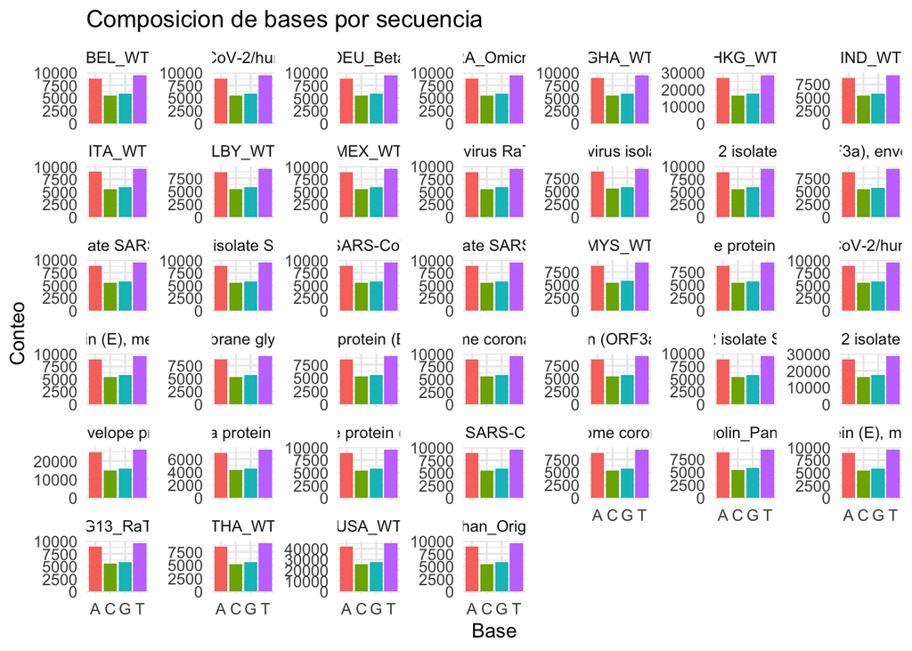

```r
# FUNCIONES PARA COMPARAR SECUENCIAS
compara_all <- function(seq_set) {
    base_levels <- c("a", "c", "g", "t")
    plot_data <- do.call(
        rbind,
        lapply(seq_along(seq_set), function(i) {
            seq_chars <- tolower(strsplit(as.character(seq_set[[i]]), "")[[1]])
            seq_table <- table(factor(seq_chars, levels = base_levels))

            data.frame(
                sequence = names(seq_set)[i],
                base = c("A", "C", "G", "T"),
                count = as.numeric(seq_table)
            )
        })
    )

    composition_plot <- ggplot(
        plot_data,
        aes(x = base, y = count, fill = base)
    ) +
        geom_col() +
        facet_wrap(~sequence, scales = "free_y") +
        labs(
            title = "Composicion de bases por secuencia",
            x = "Base",
            y = "Conteo"
        ) +
        theme_minimal() +
        theme(legend.position = "none")

    composition_plot
}

# FUNC EN ACTION
composition_plot <- compara_all(sequences)
print(composition_plot)
```

```r
ggsave(
    filename = "comparacion_fasta.png",
    plot = composition_plot,
    width = 12,
    height = 16,
    dpi = 150,
    path = getwd()
)
```

## Cálculo del porcentaje de GC

El porcentaje de GC indica la proporción de bases guanina (G) y citosina (C) en una secuencia. Para calcularlo, utilizamos la función `letterFrequency()` de Biostrings, que cuenta la frecuencia de cada base. Luego, sumamos las frecuencias de G y C, dividimos por la longitud total de la secuencia y multiplicamos por 100. Este análisis nos ayuda a identificar posibles diferencias entre variantes relacionadas con su estabilidad o capacidad de replicación.

```r
# porcentajes
gc_table <- data.frame(
    variant = names(sequences),
    gc_percent = rowSums(
        letterFrequency(sequences, letters = c("G", "C"), as.prob = TRUE)
    ) * 100
)

gc_table
```

[output not shown]

[output cut: 85 more lines]

## Interpretación de resultados

### Composición de bases y contenido GC

El análisis reveló una **composición de bases consistente** entre las variantes de SARS-CoV-2, con un sesgo hacia adenina (A) y timina (T), característico de virus ARN. El contenido promedio de GC de 37–38% es **típico para coronavirus** y se mantiene **notablemente estable** entre variantes, sugiriendo presión selectiva conservativa en la composición del genoma viral.

### Longitudes genómicas e integridad de secuencias

Las longitudes genómicas oscilan entre 29,400–29,900 nucleótidos, **consistente con el tamaño típico del genoma SARS-CoV-2** (~30 kb). La **uniformidad en las longitudes** entre variantes confirma que las mutaciones características son principalmente **sustituciones puntuales** y no grandes inserciones o deleciones, coherente con la evolución del virus mediante mutaciones acumulativas.

## Referencias

Bupa Salud. (s.f.). *Variantes de COVID-19, explicadas*. https://www.bupasalud.com/salud/varientes-covid

Charif, D. & Lobry, J. R. (2007). SeqinR 1.0-2: a contributed package to the R project for statistical computing devoted to biological sequences retrieval and analysis. En Bastolla, U., Porto, M., Roman, H. E., & Vendruscolo, M. (Eds.), *Structural approaches to sequence evolution: Molecules, networks, populations* (pp. 207–232). Springer.

Diario Cambio. (2025). *Situación del COVID-19 en Puebla: Casos y avances en la vacunación durante 2025*. https://www.diariocambio.com.mx/2025/puebla/covid-19-puebla-casos-vacunacion-2025/

Eiros, J., & Hernández, M. (2022). La evolución en variantes del SARS-CoV-2 y su repercusión clínica y sanitaria. *Revista Clínica Española*, *222*(7), 414–416. https://doi.org/10.1016/j.rce.2021.12.004

Gaceta Médica. (24 de enero de 2025). *‘Covid Frankenstein’: así es la nueva cepa que combina variantes*. https://gacetamedica.com/investigacion/covid-frankenstein-nueva-cepa-variante/

Gentleman, R., Carey, V., Huber, W., & Hahne, F. (2024). *Bioconductor: Open software development for computational biology and bioinformatics*. https://www.bioconductor.org/

Harvey, W. T., Carabelli, A. M., Jackson, B., et al. (2021). SARS-CoV-2 variants, spike mutations and immune escape. *Nature Reviews Microbiology*, *19*(7), 409–424.

Khare, S., Gurry, C., Freitas, L., et al. (2021). GISAID’s role in pandemic response. *China CDC Weekly*, *3*(49), 1049–1051.

Leite, J. A., Vicari, A., Perez, E., Siqueira, M., Resende, P., Motta, F. C., … & Mendez-Rico, J. (2022). Implementation of a COVID-19 genomic surveillance regional network for Latin America and Caribbean region. *PLoS One*, *17*(3), e0252526.

Lozano Aponte, J. (Abril 2026). *Análisis de secuencias biológicas con R/Bioconductor* [Clase magistral]. Tecnológico de Monterrey, campus Puebla.

Mayo Clinic. (2024). *Coronavirus (COVID-19): Síntomas y causas*. https://www.mayoclinic.org/es/diseases-conditions/coronavirus/symptoms-causes/syc-20479963

Morales, C. (23 de septiembre de 2025). Puebla es segundo lugar nacional en muertes por coronavirus en 2025. *Telediario*. https://www.telediario.mx/salud/puebla-es-segundo-lugar-nacional-en-muertes-por-coronavirus-en-2025

NCBI Resource Coordinators. (2024). Database resources of the National Center for Biotechnology Information. *Nucleic Acids Research*, *52*(D1), D33–D43.

Organización Panamericana de la Salud. (s.f.). *Página de inicio*. https://www.paho.org/en

Pagès, H., Aboyoun, P., Gentleman, R., & DebRoy, S. (2023). *Biostrings: Efficient manipulation of biological strings*. R package version 2.68.1. Bioconductor.

Portal informativo COVID19. (s.f.). https://previenecovid19.puebla.gob.mx/

Rambaut, A., Holmes, E. C., O’Toole, Á., et al. (2020). A dynamic nomenclature proposal for SARS-CoV-2 lineages to assist genomic epidemiology. *Nature Microbiology*, *5*(11), 1403–1407.

Secretaría de Salud. (2025). *Informes semanales para la vigilancia epidemiológica de influenza, COVID-19 y otros virus respiratorios 2025*. Gobierno de México. https://www.gob.mx/salud/documentos/informes-semanales-para-la-vigilancia-epidemiologica-de-influenza-covid-19-y-otros-virus-respiratorios-2025

Siddiqui, S., Alhamdi, H. W. S., & Alghamdi, H. A. (2022). Recent chronology of COVID-19 pandemic. *Frontiers in Public Health*, *10*, 778037. https://doi.org/10.3389/fpubh.2022.778037

Taboada, B., Zárate, S., Iša, P., Boukadida, C., Vazquez-Perez, J. A., Muñoz-Medina, J. E., … & Arias, C. F. (2021). Genetic analysis of SARS-CoV-2 variants in Mexico during the first year of the COVID-19 pandemic. *Viruses*, *13*(11), 2161. https://doi.org/10.3390/v13112161

WHO COVID-19 Dashboard. (s.f.). *Summary*. https://data.who.int/dashboards/covid19/summary

Wickham, H. (2016). *ggplot2: Elegant Graphics for Data Analysis*. Springer-Verlag New York.